# Reproducing Kernel Hilbert Space Regression

# Introduction

# Ridge Regression

## Data

```r
set.seed(3)
n = 20
x1 = runif(n)
x2 = runif(n)
X = matrix(c(x1, x2), ncol = 2) # design matrix
y = 2 + 3 * x1 + rnorm(n, sd = 0.25)
```

## Functions

### Function to find the inverse of a matrix

MC note: can use base::solve, though this function avoids a computationally singular result.

```r
my.inv = function(X, eps = 1e-12) {
  eig.X = eigen(X, symmetric = T)
  P = eig.X[[2]]
  lambda = eig.X[[1]]
  ind = lambda > eps
  lambda[ind] = 1/lambda[ind]
  lambda[!ind] = 0
  ans = P %*% diag(lambda) %*% t(P)
  return(ans)
}
```

### Reproducing Kernel

```r
rk = function(s, t) {
  crossprod(s, t)              # MC note: slightly more succinct than the original double loop; also sum(s*t)
}
```

### Gram matrix

MC note: for the first example involving ridge regression, the get.gramm function just produces tcrossprod(X). I generalize it in case a different kernel is desired and add that as an additional argument. This will avoid having to redo the function later as the authors did in their appendix.

```r
get.gramm = function(X, rkfunc=rk) {
  apply(X, 1, function(Row) apply(X, 1, function(tRow) rkfunc(Row, tRow)))
}
```

### Ridge regression

```r
ridge.regression = function(X, y, lambda) {
  Gramm = get.gramm(X)                               # Gramm matrix (nxn)
  n = length(y)                                      # n=length of y
  Q = cbind(1, Gramm)                                # design matrix
  S = rbind(0, cbind(0, Gramm))
  M = crossprod(Q) + lambda*S
  M.inv = my.inv(M)                                  # inverse of M
  gamma.hat = crossprod(M.inv, crossprod(Q, y))
  f.hat = Q %*% gamma.hat
  A = Q %*% M.inv %*% t(Q)
  tr.A = sum(diag(A))                                # trace of hat matrix
  rss = crossprod(y - f.hat)                         # residual sum of squares
  gcv = n*rss / (n - tr.A)^2                         # obtain GCV score
  return(list(f.hat = f.hat, gamma.hat = gamma.hat, gcv = gcv))
}
```

## Model results

> A simple direct search for the GCV optimal smoothing parameter can be made as follows:

```r
lambda = 1e-8
reps = 40
lambda = 1.5^(1:reps-1) * lambda
V = sapply(lambda, function(lam) ridge.regression(X, y, lam)$gcv)
```

[figure not shown]

> The GCV plot produced by this code is displayed in Figure A.2. Now, by following Section 4.2, $\hat{β_0}$, $\hat{β_1}$ and $\hat{β_2}$ can be obtained as follows.

```r
opt.mod = ridge.regression(X, y, lambda[which.min(V)])     # fit optimal model

### finding beta.0, beta.1 and beta.2 ##########
gamma.hat = opt.mod$gamma.hat
beta.hat.0 = opt.mod$gamma.hat[1]               # intercept
beta.hat = crossprod(gamma.hat[-1,], X)         # slope and noise term coefficients
```

> The resulting estimates are: $\hat{β_0}$ = 2.1253, $\hat{β_1}$ = 2.6566 and $\hat{β_2}$ = 0.1597.

MC note: I add a comparison to glmnet, where alpha=0 is equivalent to ridge regression.

```r
c(beta.hat.0, beta.hat)
```

```
## [1] 2.1253369 2.6566261 0.1597225
```

```r
coef(glmnet::glmnet(X, y, alpha=0, lambda=lambda[which.min(V)]))
```

```
## 3 x 1 sparse Matrix of class "dgCMatrix"
##                    s0
## (Intercept) 2.1360199
## V1          2.6394944
## V2          0.1552121
```

# Cubic Spline

> A.2 RKHS solution applied to Cubic Smoothing Spline  
> We consider a sample of size n = 50, ($y_1, y_2, y_3, ..., y_{50}$), from the model $y_i = sin(2πx_i) + ϵ_i$ where ϵ<sub>i</sub> has a N(0, 0.2<sup>2</sup>) . The following code generates x and y…

## Data

```r
set.seed(3)
n = 50
x = matrix(runif(n), nrow=n, ncol=1)
x.star = as.matrix(sort(x))                      # sorted x, used by plot
y = sin(2*pi*x.star) + rnorm(n, sd=0.2)
```

> Below we give a function to find the cubic smoothing spline using the RKHS framework we discussed in Section 4.3. We also provide a graph with our estimation along with the true function and data.

## Functions

### Reproducing Kernel

```r
rk.1 = function(s, t) {
  return(.5*min(s, t)^2 * max(s, t) + (1/6)*min(s, t)^3)
}
```

MC note: no need to redo the gram function do to previous change that accepts the kernel as an argument

### Smoothing Spline

```r
smoothing.spline = function(X, y, lambda) {
  Gramm = get.gramm(X, rkfunc=rk.1)                  # Gramm matrix (nxn)
  n = length(y)
  J = cbind(1, X)                                    # matrix with a basis for the null space of the penalty; MC note:, never name anything T (True) or t (transpose)!
  Q = cbind(J, Gramm)                                # design matrix
  m = ncol(J)                                        # dimension of the null space of the penalty
  S = matrix(0, n + m, n + m)                        # initialize S
  S[(m + 1):(n + m),(m + 1):(n + m)] = Gramm         # non-zero part of S
  M = crossprod(Q) + lambda*S
  M.inv = my.inv(M)                                  # inverse of M
  gamma.hat = crossprod(M.inv, crossprod(Q, y))
  f.hat = Q %*% gamma.hat
  A = Q %*% M.inv %*% t(Q)
  tr.A = sum(diag(A))                                # trace of hat matrix
  rss = crossprod(y - f.hat)                         # residual sum of squares
  gcv = n * rss/(n - tr.A)^2                         # obtain GCV score
  return(list(f.hat = f.hat, gamma.hat = gamma.hat,gcv = gcv))
}
```

## Model results

> A simple direct search for the GCV optimal smoothing parameter can be made as follows: Now we have to find an optimal lambda using GCV…

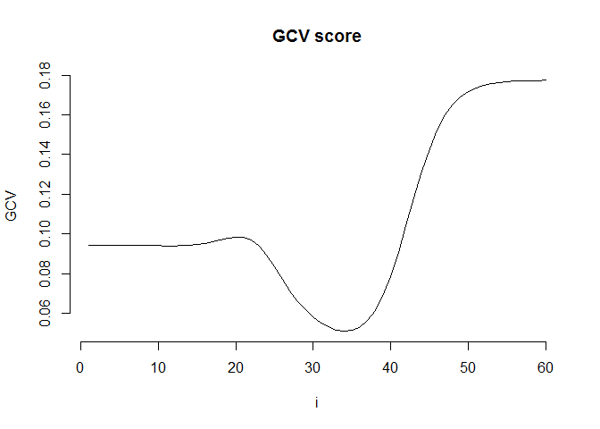

```r
lambda = 1e-8
reps = 60

lambda = 1.5^(1:reps-1) * lambda
V = sapply(lambda, function(lam) smoothing.spline(x.star, y, lam)$gcv)

# Plot of GCV
plot(1:reps, V, type = 'l', main = 'GCV score', xlab = 'i', ylab = 'GCV', bty='n')
```

MC note: I’ve added comparisons to an additive and gaussian process model.

```r
opt.mod.2 = smoothing.spline(x.star, y, lambda[which.min(V)])       # fit optimal model

# comparison models
## mgcv::gam(y ~ s(x.star))
## kernlab::gausspr(y ~ x.star, kernel='splinedot')
```

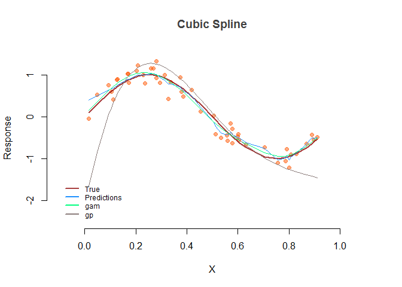

> This graph is plotted in Figure A.2.